# Deep Learning Fundamentals

## What is deep learning?

**Deep learning** is a subset of machine learning, consisting of algorithms inspired by the structure of a human brain. It is particularly useful for working with unstructured data which nevertheless follows some internal rules: images, videos, text, etc.

## Introduction to neural networks

[figure not shown]

For example, this is how the above would look for a simple home price prediction model:

[figure not shown]

Here are some examples of neural network architectures:

[figure not shown]

Here are some examples of problems which can be tackled with neural networks:

[figure not shown]

### How does it work?

[figure not shown]

```python
pip install keras --ignore-installed
```

[output not shown]

[output not shown]

```python
pip install keras
```

```python
pip install tensorflow
```

[output not shown]

[output not shown]

```python
import numpy as np

# Define input data
input_data = np.array([3,5])

#Define weights
weights = { 'node_0': np.array([2, 4]),
            'node_1': np.array([ 4, -5]),
            'output': np.array([2, 7])}

# Calculate node 0 value: node_0_value
node_0_value = (input_data * weights['node_0']).sum()
print(node_0_value)

# Calculate node 1 value: node_1_value
node_1_value = (input_data * weights['node_1']).sum()
print(node_1_value)

# Put node values into array: hidden_layer_outputs
hidden_layer_outputs = np.array([node_0_value, node_1_value])
print(hidden_layer_outputs)

# Calculate output: output
output = (hidden_layer_outputs*weights['output']).sum()

# Print output
print(output)
```

```
26
-13
[ 26 -13]
-39
```

## Activation Functions

For neural networks to achieve their maximum predictive power, we must apply something called an **activation function** in the hidden layers. An activation function allows the model to capture non-linearities - without these, our neural network would be no different from a standard linear model! These functions are asssociated to each node, and are applied to node inputs to produce node outputs:

[figure not shown]

The **Rectified Linear Unit (ReLU)** function is the most widely-used activation function in neural networks today. One of the greatest advantages ReLU has over other activation functions is that it does not activate all neurons at the same time. From the image for ReLU function above, we’ll notice that it converts all negative inputs to zero and the neuron does not get activated. This makes it very computationally efficient as few neurons are activated at any given time. In practice, ReLU converges six times faster than other functions like `tanh` and sigmoid.

```python
def relu(input):
    '''relu activation function'''
    output = max(0, input)
    return(output)

# Calculate node 0 value: node_0_output
node_0_input = (input_data * weights['node_0']).sum()
node_0_output = relu(node_0_input)

# Calculate node 1 value: node_1_output
node_1_input = (input_data * weights['node_1']).sum()
node_1_output = relu(node_1_input)

# Put node values into array: hidden_layer_outputs
hidden_layer_outputs = np.array([node_0_output, node_1_output])

# Calculate model output (do not apply relu)
model_output = (hidden_layer_outputs * weights['output']).sum()

# Print model output
print(model_output)
```

```
52
```

```python
# Define predict_with_network()
def predict_with_network(input_data_row, weights):

    # Calculate node 0 value
    node_0_input = (input_data_row * weights['node_0']).sum()
    node_0_output = relu(node_0_input)

    # Calculate node 1 value
    node_1_input = (input_data_row * weights['node_1']).sum()
    node_1_output = relu(node_1_input)

    # Put node values into array: hidden_layer_outputs
    hidden_layer_outputs = np.array([node_0_output, node_1_output])

    # Calculate model output
    input_to_final_layer = (hidden_layer_outputs * weights['output']).sum()
    model_output = relu(input_to_final_layer)

    # Return model output
    return(model_output)

input_data = [np.array([3, 5]), np.array([ 1, -1]), np.array([0, 0]), np.array([8, 4])]

# Create empty list to store prediction results
results = []
for input_data_row in input_data:
    # Append prediction to results
    results.append(predict_with_network(input_data_row,weights))

# Print results
print(results)
```

```
[52, 63, 0, 148]
```

[figure not shown]

```python
def predict_with_network(input_data):
     # Calculate node 0 in the first hidden layer
    node_0_0_input = (input_data * weights['node_0_0']).sum()
    node_0_0_output = relu(node_0_0_input)

    # Calculate node 1 in the first hidden layer
    node_0_1_input = (input_data * weights['node_0_1']).sum()
    node_0_1_output = relu(node_0_1_input)

    # Put node values into array: hidden_0_outputs
    hidden_0_outputs = np.array([node_0_0_output, node_0_1_output])

    # Calculate node 0 in the second hidden layer
    node_1_0_input = (hidden_0_outputs * weights['node_1_0']).sum()
    node_1_0_output = relu(node_1_0_input)

    # Calculate node 1 in the second hidden layer
    node_1_1_input = (hidden_0_outputs * weights['node_1_1']).sum()
    node_1_1_output = relu(node_1_1_input)

    # Put node values into array: hidden_1_outputs
    hidden_1_outputs = np.array([node_1_0_output, node_1_1_output])

    # Calculate output here: model_output
    model_output = (hidden_1_outputs * weights['output']).sum()

    # Return model_output
    return(model_output)
weights ={  'node_0_0': np.array([2, 4]),
            'node_0_1': np.array([ 4, -5]),
            'node_1_0': np.array([-1,  2]),
            'node_1_1': np.array([1, 2]),
            'output': np.array([2, 7])}

input_data = np.array([3, 5])
output = predict_with_network(input_data)
print(output)
```

```
182
```

[figure not shown]

### Optimizing weights

However, just because we have a neural network does not mean that we will have a good model. We need to optimize the weights to get this:

[figure not shown]

The **loss function** gives a single number which summarizes the degree of error in the model's predictions. Similar to the mean-squared error (MSE) of a linear moodel, the loss function gives us a sense of how well the model fits the data. Our goal then is to find the weights for the neural network which minimizes the loss function.

[figure not shown]

There is a method called **gradient descent** which we use in order to find the optimal weights. This method comes from calculus:

[figure not shown]

```python
# Define predict_with_network()
def predict_with_network(input_data_row, weights):

    # Calculate node 0 value
    node_0_input = (input_data_row * weights['node_0']).sum()
    node_0_output = relu(node_0_input)

    # Calculate node 1 value
    node_1_input = (input_data_row * weights['node_1']).sum()
    node_1_output = relu(node_1_input)

    # Put node values into array: hidden_layer_outputs
    hidden_layer_outputs = np.array([node_0_output, node_1_output])

    # Calculate model output
    input_to_final_layer = (hidden_layer_outputs * weights['output']).sum()
    model_output = relu(input_to_final_layer)

    # Return model output
    return(model_output)

# The data point you will make a prediction for
input_data = np.array([0, 3])

# Sample weights
weights_0 = {'node_0': [2, 1],
             'node_1': [1, 2],
             'output': [1, 1]
            }

# The actual target value, used to calculate the error
target_actual = 3

# Make prediction using original weights
model_output_0 = predict_with_network(input_data, weights_0)

# Calculate error: error_0
error_0 = model_output_0 - target_actual

# Create weights that cause the network to make perfect prediction (3): weights_1
weights_1 = {'node_0': [2, 1],
             'node_1': [1, 2],
             'output': [1, 0]
            }

# Make prediction using new weights: model_output_1
model_output_1 = predict_with_network(input_data, weights_1)

# Calculate error: error_1
error_1 = model_output_1 - target_actual

# Print error_0 and error_1
print(error_0)
print(error_1)
```

```
6
0
```

```python
from sklearn.metrics import mean_squared_error

# Create model_output_0
model_output_0 = []
# Create model_output_1
model_output_1 = []

input_data = [np.array([0, 3]), np.array([1, 2]), np.array([-1, -2]), np.array([4, 0])]
target_actuals = [1, 3, 5, 7]

weights_0 = {
    'node_0': np.array([2, 1]),
    'node_1': np.array([1, 2]),
    'output': np.array([1, 1])}
weights_1 = {
    'node_0': np.array([2, 1]),
    'node_1': np.array([1. , 1.5]),
    'output': np.array([1. , 1.5])}
# Loop over input_data
for row in input_data:
    # Append prediction to model_output_0
    model_output_0.append(predict_with_network(row, weights_0))

    # Append prediction to model_output_1
    model_output_1.append(predict_with_network(row, weights_1))

# Calculate the mean squared error for model_output_0: mse_0
mse_0 = mean_squared_error(target_actuals, model_output_0)

# Calculate the mean squared error for model_output_1: mse_1
mse_1 = mean_squared_error(target_actuals, model_output_1)

# Print mse_0 and mse_1
print("Mean squared error with weights_0: %f" %mse_0)
print("Mean squared error with weights_1: %f" %mse_1)
```

```
Mean squared error with weights_0: 37.500000
Mean squared error with weights_1: 49.890625
```

[figure not shown]

```python
# Calculate the predictions: preds
weights = np.array([0, 2, 1])
input_data = np.array([1, 2, 3])
target = 0

preds = (weights * input_data).sum()

# Calculate the error: error
error = preds - target

# Calculate the slope: slope
slope = input_data * error * 2

# Print the slope
print(slope)
```

```
[14 28 42]
```

```python
# Set the learning rate: learning_rate
learning_rate = 0.01

# Calculate the predictions: preds
preds = (weights * input_data).sum()

# Calculate the error: error
error = preds - target

# Calculate the slope: slope
slope = 2 * input_data * error

# Update the weights: weights_updated
weights_updated = weights - learning_rate * slope

# Get updated predictions: preds_updated
preds_updated = (weights_updated * input_data).sum()

# Calculate updated error: error_updated
error_updated = preds_updated - target

# Print the original error
print(error)

# Print the updated error
print(error_updated)
```

```
7
5.04
```

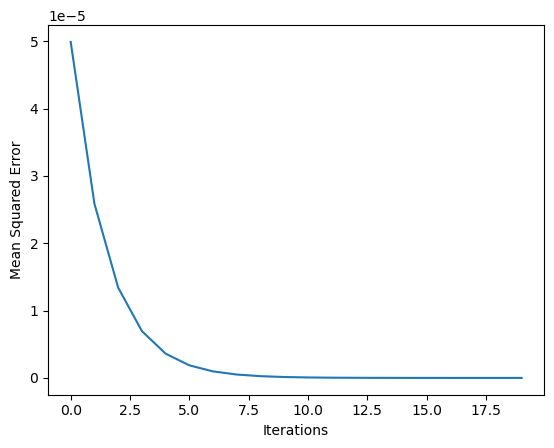

```python
import matplotlib.pyplot as plt

n_updates = 20
mse_hist = []
input_data = np.array([1, 2, 3])
target = 0
weights = np.array([-0.49929916,  1.00140168, -0.49789747])

def get_slope(input_data, target, weights):
    preds = (weights * input_data).sum()
    error = preds - target
    return input_data * error * 2

def get_mse(input_data, target, weights):
    preds = (weights * input_data).sum()
    return mean_squared_error([preds], [target])

# Iterate over the number of updates
for i in range(n_updates):
    # Calculate the slope: slope
    slope = get_slope(input_data, target, weights)
    #print(slope)
    # Update the weights: weights
    weights = weights - 0.01 * slope
    #print(weights)
    # Calculate mse with new weights: mse
    mse = get_mse(input_data, target, weights)
    #print(mse)
    # Append the mse to mse_hist
    mse_hist.append(mse)

# Plot the mse history
plt.plot(mse_hist)
plt.xlabel('Iterations')
plt.ylabel('Mean Squared Error')
plt.show()
```

[figure not shown]

## Creating a `keras` model

There are a few different libraries at our disposal for creating a neural network model:

[figure not shown]

Here, we will go with `keras`.

```python
# Complete tutorial: https://hackernoon.com/build-your-first-neural-network-to-predict-house-prices-with-keras-3fb0839680f4
import pandas as pd

df = pd.read_csv('housepricedata.csv')
df.head()
```

|  | LotArea | OverallQual | OverallCond | TotalBsmtSF | FullBath | HalfBath | BedroomAbvGr | TotRmsAbvGrd | Fireplaces | GarageArea | AboveMedianPrice |
| --- | --- | --- | --- | --- | --- | --- | --- | --- | --- | --- | --- |
| 0 | 8450 | 7 | 5 | 856 | 2 | 1 | 3 | 8 | 0 | 548 | 1 |
| 1 | 9600 | 6 | 8 | 1262 | 2 | 0 | 3 | 6 | 1 | 460 | 1 |
| 2 | 11250 | 7 | 5 | 920 | 2 | 1 | 3 | 6 | 1 | 608 | 1 |
| 3 | 9550 | 7 | 5 | 756 | 1 | 0 | 3 | 7 | 1 | 642 | 0 |
| 4 | 14260 | 8 | 5 | 1145 | 2 | 1 | 4 | 9 | 1 | 836 | 1 |

```python
dataset = df.values
```

```python
dataset
```

```
array([[ 8450,     7,     5, ...,     0,   548,     1],
       [ 9600,     6,     8, ...,     1,   460,     1],
       [11250,     7,     5, ...,     1,   608,     1],
       ...,
       [ 9042,     7,     9, ...,     2,   252,     1],
       [ 9717,     5,     6, ...,     0,   240,     0],
       [ 9937,     5,     6, ...,     0,   276,     0]], dtype=int64)
```

```python
X = dataset[:,0:10]
```

```python
Y = dataset[:,10]
```

```python
Y
```

```
array([1, 1, 1, ..., 1, 0, 0], dtype=int64)
```

```python
from sklearn import preprocessing

min_max_scaler = preprocessing.MinMaxScaler()
X_scale = min_max_scaler.fit_transform(X)
```

```python
X_scale
```

```
array([[0.0334198 , 0.66666667, 0.5       , ..., 0.5       , 0.        ,
        0.3864598 ],
       [0.03879502, 0.55555556, 0.875     , ..., 0.33333333, 0.33333333,
        0.32440056],
       [0.04650728, 0.66666667, 0.5       , ..., 0.33333333, 0.33333333,
        0.42877292],
       ...,
       [0.03618687, 0.66666667, 1.        , ..., 0.58333333, 0.66666667,
        0.17771509],
       [0.03934189, 0.44444444, 0.625     , ..., 0.25      , 0.        ,
        0.16925247],
       [0.04037019, 0.44444444, 0.625     , ..., 0.33333333, 0.        ,
        0.19464034]])
```

```python
from sklearn.model_selection import train_test_split

X_train, X_val_and_test, Y_train, Y_val_and_test = train_test_split(X_scale, Y, test_size=0.3)
```

```python
X_val, X_test, Y_val, Y_test = train_test_split(X_val_and_test, Y_val_and_test, test_size=0.5)
```

```python
print(X_train.shape, X_val.shape, X_test.shape, Y_train.shape, Y_val.shape, Y_test.shape)
```

```
(1022, 10) (219, 10) (219, 10) (1022,) (219,) (219,)
```

### Setting up the architecture

The architecture that we want to implement is this:

[figure not shown]

- Hidden layer 1: 32 neurons, ReLU activation
- Hidden layer 2: 32 neurons, ReLU activation
- Output Layer: 1 neuron, Sigmoid activation

```python
import tensorflow as tf
```

```python
pip install --upgrade numpy
```

[output not shown]

```python
from keras.models import Sequential
from keras.layers import Dense
```

```python
#  sequentially (layer by layer)
#  ‘Dense’ refers to a fully-connected layer
model = Sequential([
    Dense(32, activation='relu', input_shape=(10,)),
    Dense(32, activation='relu'),
    Dense(1, activation='sigmoid'),
])
```

```python
# ‘sgd’ refers to stochastic gradient descent
# The loss function for outputs that take the values 1 or 0 is called binary cross entropy.
# we want to track accuracy on top of the loss function
model.compile(optimizer='sgd',
              loss='binary_crossentropy',
              metrics=['accuracy'])
```

```python
hist = model.fit(X_train, Y_train,
          batch_size=32, epochs=120,
          validation_data=(X_val, Y_val))
```

```
32/32 ━━━━━━━━━━━━━━━━━━━━ 6s 6ms/step - accuracy: 0.3026 - loss: 0.7054 - val_accuracy: 0.3836 - val_loss: 0.6999
32/32 ━━━━━━━━━━━━━━━━━━━━ 0s 2ms/step - accuracy: 0.4426 - loss: 0.6996 - val_accuracy: 0.4932 - val_loss: 0.6949
32/32 ━━━━━━━━━━━━━━━━━━━━ 0s 2ms/step - accuracy: 0.5403 - loss: 0.6933 - val_accuracy: 0.5160 - val_loss: 0.6901
32/32 ━━━━━━━━━━━━━━━━━━━━ 0s 2ms/step - accuracy: 0.5578 - loss: 0.6851 - val_accuracy: 0.5205 - val_loss: 0.6851
32/32 ━━━━━━━━━━━━━━━━━━━━ 0s 2ms/step - accuracy: 0.5438 - loss: 0.6842 - val_accuracy: 0.5297 - val_loss: 0.6798
32/32 ━━━━━━━━━━━━━━━━━━━━ 0s 2ms/step - accuracy: 0.5469 - loss: 0.6761 - val_accuracy: 0.5571 - val_loss: 0.6735
32/32 ━━━━━━━━━━━━━━━━━━━━ 0s 2ms/step - accuracy: 0.6263 - loss: 0.6657 - val_accuracy: 0.6438 - val_loss: 0.6664
32/32 ━━━━━━━━━━━━━━━━━━━━ 0s 2ms/step - accuracy: 0.6975 - loss: 0.6608 - val_accuracy: 0.6712 - val_loss: 0.6592
32/32 ━━━━━━━━━━━━━━━━━━━━ 0s 2ms/step - accuracy: 0.7447 - loss: 0.6550 - val_accuracy: 0.7169 - val_loss: 0.6521
32/32 ━━━━━━━━━━━━━━━━━━━━ 0s 2ms/step - accuracy: 0.7451 - loss: 0.6438 - val_accuracy: 0.7260 - val_loss: 0.6444
32/32 ━━━━━━━━━━━━━━━━━━━━ 0s 2ms/step - accuracy: 0.7538 - loss: 0.6367 - val_accuracy: 0.7352 - val_loss: 0.6367
32/32 ━━━━━━━━━━━━━━━━━━━━ 0s 2ms/step - accuracy: 0.7727 - loss: 0.6289 - val_accuracy: 0.7489 - val_loss: 0.6289
32/32 ━━━━━━━━━━━━━━━━━━━━ 0s 2ms/step - accuracy: 0.7755 - loss: 0.6200 - val_accuracy: 0.7534 - val_loss: 0.6211
32/32 ━━━━━━━━━━━━━━━━━━━━ 0s 2ms/step - accuracy: 0.7964 - loss: 0.6090 - val_accuracy: 0.7671 - val_loss: 0.6131
32/32 ━━━━━━━━━━━━━━━━━━━━ 0s 2ms/step - accuracy: 0.7836 - loss: 0.6063 - val_accuracy: 0.7808 - val_loss: 0.6046
32/32 ━━━━━━━━━━━━━━━━━━━━ 0s 2ms/step - accuracy: 0.7911 - loss: 0.5897 - val_accuracy: 0.7808 - val_loss: 0.5961
32/32 ━━━━━━━━━━━━━━━━━━━━ 0s 2ms/step - accuracy: 0.8080 - loss: 0.5868 - val_accuracy: 0.7854 - val_loss: 0.5868
32/32 ━━━━━━━━━━━━━━━━━━━━ 0s 2ms/step - accuracy: 0.8259 - loss: 0.5675 - val_accuracy: 0.7900 - val_loss: 0.5776
32/32 ━━━━━━━━━━━━━━━━━━━━ 0s 2ms/step - accuracy: 0.8243 - loss: 0.5656 - val_accuracy: 0.7945 - val_loss: 0.5685
32/32 ━━━━━━━━━━━━━━━━━━━━ 0s 2ms/step - accuracy: 0.8416 - loss: 0.5516 - val_accuracy: 0.8128 - val_loss: 0.5591
32/32 ━━━━━━━━━━━━━━━━━━━━ 0s 2ms/step - accuracy: 0.8402 - loss: 0.5380 - val_accuracy: 0.8219 - val_loss: 0.5495
32/32 ━━━━━━━━━━━━━━━━━━━━ 0s 2ms/step - accuracy: 0.8294 - loss: 0.5307 - val_accuracy: 0.8265 - val_loss: 0.5406
32/32 ━━━━━━━━━━━━━━━━━━━━ 0s 2ms/step - accuracy: 0.8524 - loss: 0.5189 - val_accuracy: 0.8265 - val_loss: 0.5303
32/32 ━━━━━━━━━━━━━━━━━━━━ 0s 2ms/step - accuracy: 0.8437 - loss: 0.5129 - val_accuracy: 0.8311 - val_loss: 0.5211
32/32 ━━━━━━━━━━━━━━━━━━━━ 0s 2ms/step - accuracy: 0.8346 - loss: 0.5107 - val_accuracy: 0.8447 - val_loss: 0.5110
32/32 ━━━━━━━━━━━━━━━━━━━━ 0s 2ms/step - accuracy: 0.8431 - loss: 0.4984 - val_accuracy: 0.8447 - val_loss: 0.5022
32/32 ━━━━━━━━━━━━━━━━━━━━ 0s 2ms/step - accuracy: 0.8472 - loss: 0.4881 - val_accuracy: 0.8493 - val_loss: 0.4930
32/32 ━━━━━━━━━━━━━━━━━━━━ 0s 2ms/step - accuracy: 0.8470 - loss: 0.4754 - val_accuracy: 0.8493 - val_loss: 0.4839
32/32 ━━━━━━━━━━━━━━━━━━━━ 0s 2ms/step - accuracy: 0.8509 - loss: 0.4702 - val_accuracy: 0.8356 - val_loss: 0.4767
32/32 ━━━━━━━━━━━━━━━━━━━━ 0s 2ms/step - accuracy: 0.8607 - loss: 0.4495 - val_accuracy: 0.8539 - val_loss: 0.4660
32/32 ━━━━━━━━━━━━━━━━━━━━ 0s 2ms/step - accuracy: 0.8613 - loss: 0.4418 - val_accuracy: 0.8493 - val_loss: 0.4585
32/32 ━━━━━━━━━━━━━━━━━━━━ 0s 2ms/step - accuracy: 0.8688 - loss: 0.4412 - val_accuracy: 0.8493 - val_loss: 0.4496
32/32 ━━━━━━━━━━━━━━━━━━━━ 0s 2ms/step - accuracy: 0.8409 - loss: 0.4403 - val_accuracy: 0.8539 - val_loss: 0.4418
32/32 ━━━━━━━━━━━━━━━━━━━━ 0s 2ms/step - accuracy: 0.8594 - loss: 0.4306 - val_accuracy: 0.8584 - val_loss: 0.4342
32/32 ━━━━━━━━━━━━━━━━━━━━ 0s 2ms/step - accuracy: 0.8794 - loss: 0.4055 - val_accuracy: 0.8539 - val_loss: 0.4281
32/32 ━━━━━━━━━━━━━━━━━━━━ 0s 2ms/step - accuracy: 0.8956 - loss: 0.3939 - val_accuracy: 0.8584 - val_loss: 0.4193
32/32 ━━━━━━━━━━━━━━━━━━━━ 0s 2ms/step - accuracy: 0.8681 - loss: 0.3974 - val_accuracy: 0.8584 - val_loss: 0.4127
32/32 ━━━━━━━━━━━━━━━━━━━━ 0s 2ms/step - accuracy: 0.8685 - loss: 0.4001 - val_accuracy: 0.8493 - val_loss: 0.4059
32/32 ━━━━━━━━━━━━━━━━━━━━ 0s 2ms/step - accuracy: 0.8797 - loss: 0.3726 - val_accuracy: 0.8493 - val_loss: 0.4000
32/32 ━━━━━━━━━━━━━━━━━━━━ 0s 2ms/step - accuracy: 0.8764 - loss: 0.3704 - val_accuracy: 0.8493 - val_loss: 0.3952
```

[output cut: 65 more lines]

```
32/32 ━━━━━━━━━━━━━━━━━━━━ 0s 2ms/step - accuracy: 0.8955 - loss: 0.2458 - val_accuracy: 0.8676 - val_loss: 0.2962
32/32 ━━━━━━━━━━━━━━━━━━━━ 0s 2ms/step - accuracy: 0.9030 - loss: 0.2710 - val_accuracy: 0.8721 - val_loss: 0.3038
32/32 ━━━━━━━━━━━━━━━━━━━━ 0s 2ms/step - accuracy: 0.8929 - loss: 0.2545 - val_accuracy: 0.8721 - val_loss: 0.2964
32/32 ━━━━━━━━━━━━━━━━━━━━ 0s 2ms/step - accuracy: 0.9123 - loss: 0.2304 - val_accuracy: 0.8767 - val_loss: 0.2996
32/32 ━━━━━━━━━━━━━━━━━━━━ 0s 2ms/step - accuracy: 0.8943 - loss: 0.2700 - val_accuracy: 0.8767 - val_loss: 0.3057
32/32 ━━━━━━━━━━━━━━━━━━━━ 0s 2ms/step - accuracy: 0.9039 - loss: 0.2446 - val_accuracy: 0.8721 - val_loss: 0.3011
32/32 ━━━━━━━━━━━━━━━━━━━━ 0s 2ms/step - accuracy: 0.8934 - loss: 0.2505 - val_accuracy: 0.8767 - val_loss: 0.2983
32/32 ━━━━━━━━━━━━━━━━━━━━ 0s 2ms/step - accuracy: 0.9008 - loss: 0.2571 - val_accuracy: 0.8767 - val_loss: 0.3035
32/32 ━━━━━━━━━━━━━━━━━━━━ 0s 2ms/step - accuracy: 0.8837 - loss: 0.2849 - val_accuracy: 0.8721 - val_loss: 0.3004
32/32 ━━━━━━━━━━━━━━━━━━━━ 0s 2ms/step - accuracy: 0.9008 - loss: 0.2439 - val_accuracy: 0.8767 - val_loss: 0.2960
32/32 ━━━━━━━━━━━━━━━━━━━━ 0s 2ms/step - accuracy: 0.9001 - loss: 0.2653 - val_accuracy: 0.8767 - val_loss: 0.2964
32/32 ━━━━━━━━━━━━━━━━━━━━ 0s 2ms/step - accuracy: 0.8998 - loss: 0.2465 - val_accuracy: 0.8767 - val_loss: 0.2946
32/32 ━━━━━━━━━━━━━━━━━━━━ 0s 2ms/step - accuracy: 0.8971 - loss: 0.2638 - val_accuracy: 0.8767 - val_loss: 0.2978
32/32 ━━━━━━━━━━━━━━━━━━━━ 0s 2ms/step - accuracy: 0.8739 - loss: 0.3008 - val_accuracy: 0.8767 - val_loss: 0.2973
32/32 ━━━━━━━━━━━━━━━━━━━━ 0s 2ms/step - accuracy: 0.8959 - loss: 0.2637 - val_accuracy: 0.8767 - val_loss: 0.2974
```

```python
# The reason why we have the index 1 after the model.evaluate function is because the function returns the loss as the first element and the accuracy as the second element.
model.evaluate(X_test, Y_test)[1]
```

```
7/7 ━━━━━━━━━━━━━━━━━━━━ 0s 1ms/step - accuracy: 0.8622 - loss: 0.3115
```

```
0.8721461296081543
```

### Visualizing loss and accuracy

[figure not shown]

A good model is one where the testing and training set errors are very similar, and at their lowest point.

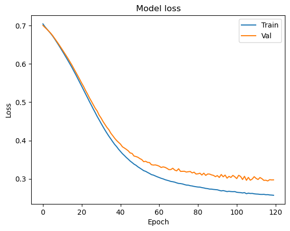

```python
import matplotlib.pyplot as plt

plt.plot(hist.history['loss'])
plt.plot(hist.history['val_loss'])
plt.title('Model loss')
plt.ylabel('Loss')
plt.xlabel('Epoch')
plt.legend(['Train', 'Val'], loc='upper right')
plt.show()
```

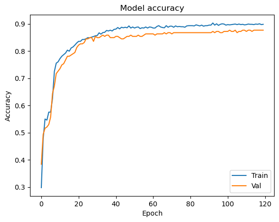

```python
plt.plot(hist.history['accuracy'])
plt.plot(hist.history['val_accuracy'])
plt.title('Model accuracy')
plt.ylabel('Accuracy')
plt.xlabel('Epoch')
plt.legend(['Train', 'Val'], loc='lower right')
plt.show()
```

### Adding regularization to our network

- L2 Regularization

[figure not shown]

- Early Stopping

[figure not shown]

- Dropout

[figure not shown]

```python
model_2 = Sequential([
    Dense(1000, activation='relu', input_shape=(10,)),
    Dense(1000, activation='relu'),
    Dense(1000, activation='relu'),
    Dense(1000, activation='relu'),
    Dense(1, activation='sigmoid'),
])
```

```python
model_2.compile(optimizer='adam',
              loss='binary_crossentropy',
              metrics=['accuracy'])
```

```python
hist_2 = model_2.fit(X_train, Y_train,
          batch_size=32, epochs=100,
          validation_data=(X_val, Y_val))
```

```
32/32 ━━━━━━━━━━━━━━━━━━━━ 2s 36ms/step - accuracy: 0.6933 - loss: 0.5362 - val_accuracy: 0.8402 - val_loss: 0.3980
32/32 ━━━━━━━━━━━━━━━━━━━━ 1s 30ms/step - accuracy: 0.8830 - loss: 0.3051 - val_accuracy: 0.8676 - val_loss: 0.3529
32/32 ━━━━━━━━━━━━━━━━━━━━ 1s 30ms/step - accuracy: 0.8569 - loss: 0.3167 - val_accuracy: 0.8402 - val_loss: 0.3662
32/32 ━━━━━━━━━━━━━━━━━━━━ 1s 30ms/step - accuracy: 0.8751 - loss: 0.2904 - val_accuracy: 0.8858 - val_loss: 0.2986
32/32 ━━━━━━━━━━━━━━━━━━━━ 1s 30ms/step - accuracy: 0.8847 - loss: 0.2743 - val_accuracy: 0.8402 - val_loss: 0.3169
32/32 ━━━━━━━━━━━━━━━━━━━━ 1s 30ms/step - accuracy: 0.8920 - loss: 0.2421 - val_accuracy: 0.8904 - val_loss: 0.3008
32/32 ━━━━━━━━━━━━━━━━━━━━ 1s 30ms/step - accuracy: 0.9089 - loss: 0.2160 - val_accuracy: 0.8813 - val_loss: 0.2874
32/32 ━━━━━━━━━━━━━━━━━━━━ 1s 30ms/step - accuracy: 0.8982 - loss: 0.2156 - val_accuracy: 0.8950 - val_loss: 0.2908
32/32 ━━━━━━━━━━━━━━━━━━━━ 1s 30ms/step - accuracy: 0.8814 - loss: 0.2261 - val_accuracy: 0.8858 - val_loss: 0.2708
32/32 ━━━━━━━━━━━━━━━━━━━━ 1s 30ms/step - accuracy: 0.9177 - loss: 0.1967 - val_accuracy: 0.8858 - val_loss: 0.3077
32/32 ━━━━━━━━━━━━━━━━━━━━ 1s 31ms/step - accuracy: 0.8955 - loss: 0.2449 - val_accuracy: 0.8721 - val_loss: 0.3327
32/32 ━━━━━━━━━━━━━━━━━━━━ 1s 30ms/step - accuracy: 0.9157 - loss: 0.2270 - val_accuracy: 0.8813 - val_loss: 0.3561
32/32 ━━━━━━━━━━━━━━━━━━━━ 1s 31ms/step - accuracy: 0.9188 - loss: 0.1994 - val_accuracy: 0.9087 - val_loss: 0.2975
32/32 ━━━━━━━━━━━━━━━━━━━━ 1s 30ms/step - accuracy: 0.9028 - loss: 0.2353 - val_accuracy: 0.8995 - val_loss: 0.2499
32/32 ━━━━━━━━━━━━━━━━━━━━ 1s 30ms/step - accuracy: 0.9158 - loss: 0.1931 - val_accuracy: 0.8904 - val_loss: 0.2981
32/32 ━━━━━━━━━━━━━━━━━━━━ 1s 30ms/step - accuracy: 0.9005 - loss: 0.2025 - val_accuracy: 0.8858 - val_loss: 0.2812
32/32 ━━━━━━━━━━━━━━━━━━━━ 1s 30ms/step - accuracy: 0.9248 - loss: 0.1902 - val_accuracy: 0.8950 - val_loss: 0.2633
32/32 ━━━━━━━━━━━━━━━━━━━━ 1s 30ms/step - accuracy: 0.9003 - loss: 0.2019 - val_accuracy: 0.8813 - val_loss: 0.3068
32/32 ━━━━━━━━━━━━━━━━━━━━ 1s 31ms/step - accuracy: 0.8916 - loss: 0.2178 - val_accuracy: 0.8767 - val_loss: 0.3386
32/32 ━━━━━━━━━━━━━━━━━━━━ 1s 31ms/step - accuracy: 0.9088 - loss: 0.2072 - val_accuracy: 0.8904 - val_loss: 0.2730
32/32 ━━━━━━━━━━━━━━━━━━━━ 1s 30ms/step - accuracy: 0.9123 - loss: 0.1862 - val_accuracy: 0.8858 - val_loss: 0.3102
32/32 ━━━━━━━━━━━━━━━━━━━━ 1s 30ms/step - accuracy: 0.9248 - loss: 0.1884 - val_accuracy: 0.8813 - val_loss: 0.2707
32/32 ━━━━━━━━━━━━━━━━━━━━ 1s 31ms/step - accuracy: 0.9115 - loss: 0.2170 - val_accuracy: 0.9087 - val_loss: 0.2581
32/32 ━━━━━━━━━━━━━━━━━━━━ 1s 30ms/step - accuracy: 0.9242 - loss: 0.1613 - val_accuracy: 0.9041 - val_loss: 0.2681
32/32 ━━━━━━━━━━━━━━━━━━━━ 1s 30ms/step - accuracy: 0.9429 - loss: 0.1573 - val_accuracy: 0.8858 - val_loss: 0.3095
32/32 ━━━━━━━━━━━━━━━━━━━━ 1s 30ms/step - accuracy: 0.8806 - loss: 0.2383 - val_accuracy: 0.9041 - val_loss: 0.3351
32/32 ━━━━━━━━━━━━━━━━━━━━ 1s 31ms/step - accuracy: 0.9223 - loss: 0.2047 - val_accuracy: 0.8950 - val_loss: 0.2758
32/32 ━━━━━━━━━━━━━━━━━━━━ 1s 31ms/step - accuracy: 0.9204 - loss: 0.2035 - val_accuracy: 0.8950 - val_loss: 0.3025
32/32 ━━━━━━━━━━━━━━━━━━━━ 1s 31ms/step - accuracy: 0.9142 - loss: 0.1862 - val_accuracy: 0.8813 - val_loss: 0.3187
32/32 ━━━━━━━━━━━━━━━━━━━━ 1s 30ms/step - accuracy: 0.9198 - loss: 0.2081 - val_accuracy: 0.8676 - val_loss: 0.3196
32/32 ━━━━━━━━━━━━━━━━━━━━ 1s 30ms/step - accuracy: 0.9220 - loss: 0.1819 - val_accuracy: 0.8858 - val_loss: 0.3444
32/32 ━━━━━━━━━━━━━━━━━━━━ 1s 32ms/step - accuracy: 0.9274 - loss: 0.1954 - val_accuracy: 0.8950 - val_loss: 0.2725
32/32 ━━━━━━━━━━━━━━━━━━━━ 1s 31ms/step - accuracy: 0.9276 - loss: 0.1537 - val_accuracy: 0.8721 - val_loss: 0.2776
32/32 ━━━━━━━━━━━━━━━━━━━━ 1s 31ms/step - accuracy: 0.9163 - loss: 0.2036 - val_accuracy: 0.8813 - val_loss: 0.3275
32/32 ━━━━━━━━━━━━━━━━━━━━ 1s 31ms/step - accuracy: 0.9315 - loss: 0.1578 - val_accuracy: 0.8813 - val_loss: 0.3126
32/32 ━━━━━━━━━━━━━━━━━━━━ 1s 31ms/step - accuracy: 0.9398 - loss: 0.1615 - val_accuracy: 0.8767 - val_loss: 0.3099
32/32 ━━━━━━━━━━━━━━━━━━━━ 1s 30ms/step - accuracy: 0.9204 - loss: 0.1786 - val_accuracy: 0.8767 - val_loss: 0.3328
32/32 ━━━━━━━━━━━━━━━━━━━━ 1s 30ms/step - accuracy: 0.9293 - loss: 0.1520 - val_accuracy: 0.8858 - val_loss: 0.3166
32/32 ━━━━━━━━━━━━━━━━━━━━ 1s 32ms/step - accuracy: 0.9458 - loss: 0.1556 - val_accuracy: 0.8950 - val_loss: 0.2961
32/32 ━━━━━━━━━━━━━━━━━━━━ 1s 32ms/step - accuracy: 0.9404 - loss: 0.1518 - val_accuracy: 0.8904 - val_loss: 0.3140
```

[output cut: 45 more lines]

```
32/32 ━━━━━━━━━━━━━━━━━━━━ 1s 32ms/step - accuracy: 0.9555 - loss: 0.0994 - val_accuracy: 0.8539 - val_loss: 0.4799
32/32 ━━━━━━━━━━━━━━━━━━━━ 1s 32ms/step - accuracy: 0.9604 - loss: 0.1070 - val_accuracy: 0.8721 - val_loss: 0.4766
32/32 ━━━━━━━━━━━━━━━━━━━━ 1s 32ms/step - accuracy: 0.9469 - loss: 0.1307 - val_accuracy: 0.8584 - val_loss: 0.5615
32/32 ━━━━━━━━━━━━━━━━━━━━ 1s 33ms/step - accuracy: 0.9598 - loss: 0.0964 - val_accuracy: 0.8630 - val_loss: 0.5587
32/32 ━━━━━━━━━━━━━━━━━━━━ 1s 33ms/step - accuracy: 0.9585 - loss: 0.1038 - val_accuracy: 0.8584 - val_loss: 0.5012
32/32 ━━━━━━━━━━━━━━━━━━━━ 1s 33ms/step - accuracy: 0.9333 - loss: 0.1399 - val_accuracy: 0.8584 - val_loss: 0.5080
32/32 ━━━━━━━━━━━━━━━━━━━━ 1s 33ms/step - accuracy: 0.9430 - loss: 0.1256 - val_accuracy: 0.8584 - val_loss: 0.4689
32/32 ━━━━━━━━━━━━━━━━━━━━ 1s 32ms/step - accuracy: 0.9614 - loss: 0.1020 - val_accuracy: 0.8813 - val_loss: 0.3419
32/32 ━━━━━━━━━━━━━━━━━━━━ 1s 32ms/step - accuracy: 0.9460 - loss: 0.1450 - val_accuracy: 0.8676 - val_loss: 0.3180
32/32 ━━━━━━━━━━━━━━━━━━━━ 1s 32ms/step - accuracy: 0.9507 - loss: 0.1328 - val_accuracy: 0.8721 - val_loss: 0.4729
32/32 ━━━━━━━━━━━━━━━━━━━━ 1s 33ms/step - accuracy: 0.9563 - loss: 0.1054 - val_accuracy: 0.8584 - val_loss: 0.4378
32/32 ━━━━━━━━━━━━━━━━━━━━ 1s 33ms/step - accuracy: 0.9551 - loss: 0.1051 - val_accuracy: 0.8584 - val_loss: 0.5623
32/32 ━━━━━━━━━━━━━━━━━━━━ 1s 32ms/step - accuracy: 0.9497 - loss: 0.1155 - val_accuracy: 0.8676 - val_loss: 0.5777
32/32 ━━━━━━━━━━━━━━━━━━━━ 1s 31ms/step - accuracy: 0.9406 - loss: 0.1571 - val_accuracy: 0.8584 - val_loss: 0.5068
32/32 ━━━━━━━━━━━━━━━━━━━━ 1s 31ms/step - accuracy: 0.9536 - loss: 0.1118 - val_accuracy: 0.8630 - val_loss: 0.5099
```

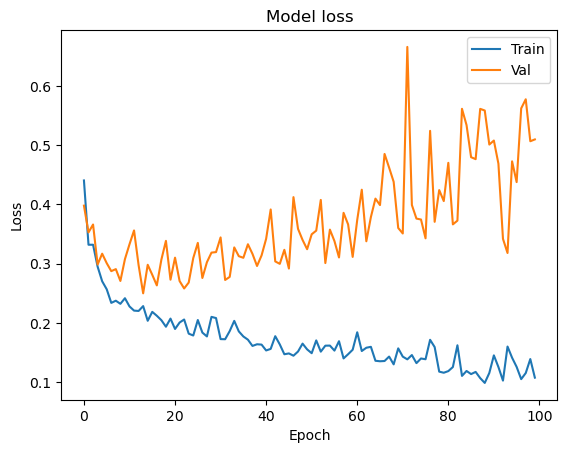

```python
plt.plot(hist_2.history['loss'])
plt.plot(hist_2.history['val_loss'])
plt.title('Model loss')
plt.ylabel('Loss')
plt.xlabel('Epoch')
plt.legend(['Train', 'Val'], loc='upper right')
plt.show()
```

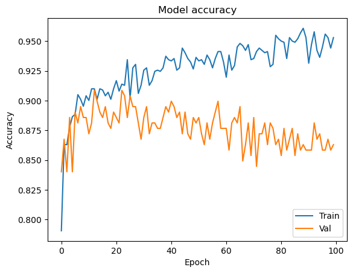

```python
plt.plot(hist_2.history['accuracy'])
plt.plot(hist_2.history['val_accuracy'])
plt.title('Model accuracy')
plt.ylabel('Accuracy')
plt.xlabel('Epoch')
plt.legend(['Train', 'Val'], loc='lower right')
plt.show()
```

```python
from keras.layers import Dropout
from keras import regularizers
```

```python
model_3 = Sequential([
    Dense(1000, activation='relu', kernel_regularizer=regularizers.l2(0.01), input_shape=(10,)),
    Dropout(0.3),
    Dense(1000, activation='relu', kernel_regularizer=regularizers.l2(0.01)),
    Dropout(0.3),
    Dense(1000, activation='relu', kernel_regularizer=regularizers.l2(0.01)),
    Dropout(0.3),
    Dense(1000, activation='relu', kernel_regularizer=regularizers.l2(0.01)),
    Dropout(0.3),
    Dense(1, activation='sigmoid', kernel_regularizer=regularizers.l2(0.01)),
])
```

```python
model_3.compile(optimizer='adam',
              loss='binary_crossentropy',
              metrics=['accuracy'])
```

```python
hist_3 = model_3.fit(X_train, Y_train,
          batch_size=32, epochs=100,
          validation_data=(X_val, Y_val))
```

```
32/32 ━━━━━━━━━━━━━━━━━━━━ 3s 46ms/step - accuracy: 0.5387 - loss: 21.1177 - val_accuracy: 0.8311 - val_loss: 3.9268
32/32 ━━━━━━━━━━━━━━━━━━━━ 1s 42ms/step - accuracy: 0.8221 - loss: 2.4982 - val_accuracy: 0.8539 - val_loss: 0.6697
32/32 ━━━━━━━━━━━━━━━━━━━━ 1s 41ms/step - accuracy: 0.8457 - loss: 0.6156 - val_accuracy: 0.8493 - val_loss: 0.6078
32/32 ━━━━━━━━━━━━━━━━━━━━ 1s 42ms/step - accuracy: 0.8859 - loss: 0.4978 - val_accuracy: 0.8721 - val_loss: 0.5286
32/32 ━━━━━━━━━━━━━━━━━━━━ 1s 43ms/step - accuracy: 0.8570 - loss: 0.4983 - val_accuracy: 0.8721 - val_loss: 0.4787
32/32 ━━━━━━━━━━━━━━━━━━━━ 1s 40ms/step - accuracy: 0.8859 - loss: 0.4816 - val_accuracy: 0.8721 - val_loss: 0.4758
32/32 ━━━━━━━━━━━━━━━━━━━━ 1s 40ms/step - accuracy: 0.8718 - loss: 0.4719 - val_accuracy: 0.8721 - val_loss: 0.4904
32/32 ━━━━━━━━━━━━━━━━━━━━ 1s 41ms/step - accuracy: 0.8903 - loss: 0.4411 - val_accuracy: 0.8721 - val_loss: 0.4544
32/32 ━━━━━━━━━━━━━━━━━━━━ 1s 45ms/step - accuracy: 0.8772 - loss: 0.4457 - val_accuracy: 0.8767 - val_loss: 0.4619
32/32 ━━━━━━━━━━━━━━━━━━━━ 1s 42ms/step - accuracy: 0.8883 - loss: 0.4458 - val_accuracy: 0.8767 - val_loss: 0.4491
32/32 ━━━━━━━━━━━━━━━━━━━━ 1s 40ms/step - accuracy: 0.8879 - loss: 0.4462 - val_accuracy: 0.8767 - val_loss: 0.4532
32/32 ━━━━━━━━━━━━━━━━━━━━ 1s 42ms/step - accuracy: 0.9002 - loss: 0.4379 - val_accuracy: 0.8767 - val_loss: 0.4505
32/32 ━━━━━━━━━━━━━━━━━━━━ 1s 45ms/step - accuracy: 0.8918 - loss: 0.4446 - val_accuracy: 0.8721 - val_loss: 0.4461
32/32 ━━━━━━━━━━━━━━━━━━━━ 1s 45ms/step - accuracy: 0.8884 - loss: 0.4344 - val_accuracy: 0.8767 - val_loss: 0.4458
32/32 ━━━━━━━━━━━━━━━━━━━━ 1s 40ms/step - accuracy: 0.8926 - loss: 0.4291 - val_accuracy: 0.8813 - val_loss: 0.4509
32/32 ━━━━━━━━━━━━━━━━━━━━ 1s 40ms/step - accuracy: 0.8678 - loss: 0.4572 - val_accuracy: 0.8767 - val_loss: 0.4482
32/32 ━━━━━━━━━━━━━━━━━━━━ 1s 40ms/step - accuracy: 0.8830 - loss: 0.4598 - val_accuracy: 0.8813 - val_loss: 0.4497
32/32 ━━━━━━━━━━━━━━━━━━━━ 2s 47ms/step - accuracy: 0.8887 - loss: 0.4454 - val_accuracy: 0.8721 - val_loss: 0.4397
32/32 ━━━━━━━━━━━━━━━━━━━━ 1s 40ms/step - accuracy: 0.8827 - loss: 0.4376 - val_accuracy: 0.8813 - val_loss: 0.4426
32/32 ━━━━━━━━━━━━━━━━━━━━ 1s 46ms/step - accuracy: 0.9027 - loss: 0.4246 - val_accuracy: 0.8767 - val_loss: 0.4814
32/32 ━━━━━━━━━━━━━━━━━━━━ 1s 41ms/step - accuracy: 0.8817 - loss: 0.4475 - val_accuracy: 0.8813 - val_loss: 0.4332
32/32 ━━━━━━━━━━━━━━━━━━━━ 1s 41ms/step - accuracy: 0.8810 - loss: 0.4334 - val_accuracy: 0.8767 - val_loss: 0.4741
32/32 ━━━━━━━━━━━━━━━━━━━━ 1s 41ms/step - accuracy: 0.8849 - loss: 0.4737 - val_accuracy: 0.8858 - val_loss: 0.4475
32/32 ━━━━━━━━━━━━━━━━━━━━ 1s 40ms/step - accuracy: 0.8928 - loss: 0.4350 - val_accuracy: 0.8721 - val_loss: 0.4529
32/32 ━━━━━━━━━━━━━━━━━━━━ 1s 42ms/step - accuracy: 0.8944 - loss: 0.4360 - val_accuracy: 0.8767 - val_loss: 0.4788
32/32 ━━━━━━━━━━━━━━━━━━━━ 1s 40ms/step - accuracy: 0.8799 - loss: 0.4576 - val_accuracy: 0.8813 - val_loss: 0.4457
32/32 ━━━━━━━━━━━━━━━━━━━━ 1s 40ms/step - accuracy: 0.8990 - loss: 0.4121 - val_accuracy: 0.8813 - val_loss: 0.4384
32/32 ━━━━━━━━━━━━━━━━━━━━ 1s 40ms/step - accuracy: 0.8694 - loss: 0.4552 - val_accuracy: 0.8813 - val_loss: 0.4879
32/32 ━━━━━━━━━━━━━━━━━━━━ 1s 40ms/step - accuracy: 0.8696 - loss: 0.4670 - val_accuracy: 0.8767 - val_loss: 0.4466
32/32 ━━━━━━━━━━━━━━━━━━━━ 1s 40ms/step - accuracy: 0.8883 - loss: 0.4233 - val_accuracy: 0.8630 - val_loss: 0.4333
32/32 ━━━━━━━━━━━━━━━━━━━━ 1s 43ms/step - accuracy: 0.8732 - loss: 0.4573 - val_accuracy: 0.8858 - val_loss: 0.4340
32/32 ━━━━━━━━━━━━━━━━━━━━ 1s 40ms/step - accuracy: 0.8721 - loss: 0.4565 - val_accuracy: 0.8767 - val_loss: 0.4706
32/32 ━━━━━━━━━━━━━━━━━━━━ 1s 41ms/step - accuracy: 0.8985 - loss: 0.4354 - val_accuracy: 0.8767 - val_loss: 0.4327
32/32 ━━━━━━━━━━━━━━━━━━━━ 1s 41ms/step - accuracy: 0.8809 - loss: 0.4506 - val_accuracy: 0.8721 - val_loss: 0.4318
32/32 ━━━━━━━━━━━━━━━━━━━━ 1s 42ms/step - accuracy: 0.8740 - loss: 0.4723 - val_accuracy: 0.8676 - val_loss: 0.5363
32/32 ━━━━━━━━━━━━━━━━━━━━ 1s 42ms/step - accuracy: 0.8731 - loss: 0.4497 - val_accuracy: 0.8813 - val_loss: 0.4321
32/32 ━━━━━━━━━━━━━━━━━━━━ 2s 51ms/step - accuracy: 0.9141 - loss: 0.4046 - val_accuracy: 0.8813 - val_loss: 0.4344
32/32 ━━━━━━━━━━━━━━━━━━━━ 1s 45ms/step - accuracy: 0.8757 - loss: 0.4443 - val_accuracy: 0.8858 - val_loss: 0.4318
32/32 ━━━━━━━━━━━━━━━━━━━━ 1s 42ms/step - accuracy: 0.8902 - loss: 0.4188 - val_accuracy: 0.8813 - val_loss: 0.4328
32/32 ━━━━━━━━━━━━━━━━━━━━ 1s 43ms/step - accuracy: 0.8820 - loss: 0.4437 - val_accuracy: 0.8813 - val_loss: 0.4368
```

[output cut: 45 more lines]

```
32/32 ━━━━━━━━━━━━━━━━━━━━ 1s 42ms/step - accuracy: 0.8977 - loss: 0.4091 - val_accuracy: 0.8767 - val_loss: 0.4250
32/32 ━━━━━━━━━━━━━━━━━━━━ 1s 41ms/step - accuracy: 0.8897 - loss: 0.4260 - val_accuracy: 0.8767 - val_loss: 0.4531
32/32 ━━━━━━━━━━━━━━━━━━━━ 1s 41ms/step - accuracy: 0.8788 - loss: 0.4461 - val_accuracy: 0.8858 - val_loss: 0.4426
32/32 ━━━━━━━━━━━━━━━━━━━━ 1s 41ms/step - accuracy: 0.8796 - loss: 0.4450 - val_accuracy: 0.8767 - val_loss: 0.4533
32/32 ━━━━━━━━━━━━━━━━━━━━ 1s 41ms/step - accuracy: 0.8843 - loss: 0.4423 - val_accuracy: 0.8858 - val_loss: 0.4393
32/32 ━━━━━━━━━━━━━━━━━━━━ 1s 41ms/step - accuracy: 0.8816 - loss: 0.4336 - val_accuracy: 0.8858 - val_loss: 0.4239
32/32 ━━━━━━━━━━━━━━━━━━━━ 1s 40ms/step - accuracy: 0.8927 - loss: 0.4255 - val_accuracy: 0.8630 - val_loss: 0.4404
32/32 ━━━━━━━━━━━━━━━━━━━━ 1s 43ms/step - accuracy: 0.8761 - loss: 0.4472 - val_accuracy: 0.8858 - val_loss: 0.4894
32/32 ━━━━━━━━━━━━━━━━━━━━ 1s 42ms/step - accuracy: 0.8866 - loss: 0.4152 - val_accuracy: 0.8813 - val_loss: 0.4441
32/32 ━━━━━━━━━━━━━━━━━━━━ 1s 41ms/step - accuracy: 0.8735 - loss: 0.4333 - val_accuracy: 0.8858 - val_loss: 0.4353
32/32 ━━━━━━━━━━━━━━━━━━━━ 1s 40ms/step - accuracy: 0.8951 - loss: 0.4256 - val_accuracy: 0.8721 - val_loss: 0.4302
32/32 ━━━━━━━━━━━━━━━━━━━━ 1s 40ms/step - accuracy: 0.8850 - loss: 0.4461 - val_accuracy: 0.8858 - val_loss: 0.4246
32/32 ━━━━━━━━━━━━━━━━━━━━ 1s 40ms/step - accuracy: 0.8978 - loss: 0.3946 - val_accuracy: 0.8767 - val_loss: 0.4297
32/32 ━━━━━━━━━━━━━━━━━━━━ 1s 41ms/step - accuracy: 0.8726 - loss: 0.4455 - val_accuracy: 0.8813 - val_loss: 0.4510
32/32 ━━━━━━━━━━━━━━━━━━━━ 1s 42ms/step - accuracy: 0.8953 - loss: 0.4199 - val_accuracy: 0.8584 - val_loss: 0.4468
```

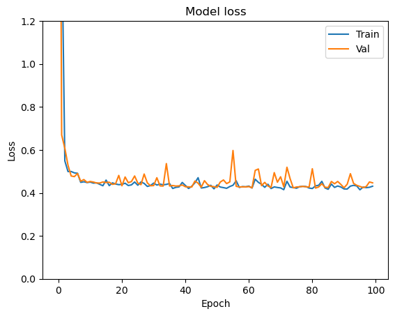

```python
plt.plot(hist_3.history['loss'])
plt.plot(hist_3.history['val_loss'])
plt.title('Model loss')
plt.ylabel('Loss')
plt.xlabel('Epoch')
plt.legend(['Train', 'Val'], loc='upper right')
plt.ylim(top=1.2, bottom=0)
plt.show()
```

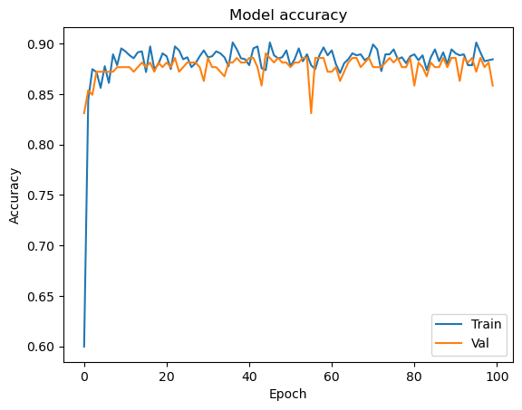

```python
plt.plot(hist_3.history['accuracy'])
plt.plot(hist_3.history['val_accuracy'])
plt.title('Model accuracy')
plt.ylabel('Accuracy')
plt.xlabel('Epoch')
plt.legend(['Train', 'Val'], loc='lower right')
plt.show()
```

```python
import numpy as np

array1 = np.array([1, 1])        # Shape (2,)
array2 = np.array([1, 1, 1])     # Shape (3,)

print(" ARRAY 1")
print(array1)
print(" ARRAY 2")
print(array2)
print("****************")

# Expandir dimensiones para hacer broadcasting explícito
array1 = np.expand_dims(array1, axis=0)  # Shape (1, 2)
array2 = np.expand_dims(array2, axis=1)  # Shape (3, 1)

print("expandidos ARRAY 1")
print(array1)
print("expandidos ARRAY 2")
print(array2)
print("****************")

# Multiplicar con broadcasting
result = array1 * array2
print(result)
```

```
 ARRAY 1
[1 1]
 ARRAY 2
[1 1 1]
****************
expandidos ARRAY 1
[[1 1]]
expandidos ARRAY 2
[[1]
 [1]
 [1]]
****************
[[1 1]
 [1 1]
 [1 1]]
```